# Praktikum 3

Atika Fawwaz G1401231038

2025-09-14

# Library

```r
library(dLagM)
library(dynlm)
library(MLmetrics)
library(lmtest)
library(car)
library(readr)
```

```r
library(ggplot2)
library(rio)
library(corrplot)
```

# Import Data

```r
data_aqi <- rio::import("https://raw.githubusercontent.com/atikafawwaz/mpdw/refs/heads/main/Pertemuan%203/NewDelhi_Air_quality.csv")
str(data_aqi)
```

```
## 'data.frame':    72 obs. of  12 variables:
##  $ V1             : int  0 1 2 3 4 5 6 7 8 9 ...
##  $ AQI            : num  30.2 28.2 26.6 25 26 26 26 24 23 24 ...
##  $ CO             : num  199 198 199 202 205 ...
##  $ datetime       : chr  "2022-10-21:18" "2022-10-21:19" "2022-10-21:20" "2022-10-21:21" ...
##  $ no2            : num  0.0469 0.0465 0.0469 0.0482 0.0489 ...
##  $ o3             : num  55.8 54.9 54.6 55.1 55.8 ...
##  $ pm10           : num  10.5 10.7 11.2 11.1 10.4 ...
##  $ pm25           : num  5.64 4.62 3.52 2.23 1.98 ...
##  $ so2            : num  0.387 0.41 0.402 0.376 0.339 ...
##  $ timestamp_local: POSIXct, format: "2022-10-21 23:00:00" "2022-10-22 00:00:00" ...
##  $ timestamp_utc  : POSIXct, format: "2022-10-21 18:00:00" "2022-10-21 19:00:00" ...
##  $ ts             : int  1666375200 1666378800 1666382400 1666386000 1666389600 1666393200 1666396800 1666400400 1666404000 1666407600 ...
```

```r
data_aqi
```

```
##    V1  AQI       CO      datetime        no2       o3      pm10     pm25
## 1   0 30.2 198.6027 2022-10-21:18 0.04685717 55.78995 10.486722 5.637410
## 2   1 28.2 197.6013 2022-10-21:19 0.04645554 54.93164 10.719325 4.618169
## 3   2 26.6 198.6027 2022-10-21:20 0.04685717 54.64554 11.155578 3.520902
## 4   3 25.0 201.9405 2022-10-21:21 0.04819594 55.07469 11.116206 2.225919
## 5   4 26.0 205.2784 2022-10-21:22 0.04886533 55.78995 10.405250 1.979471
## 6   5 26.0 208.6163 2022-10-21:23 0.05020411 56.50520  9.402518 1.792677
## 7   6 26.0 208.6163 2022-10-22:00 0.05020411 55.78995  8.482822 1.752237
## 8   7 24.0 205.2784 2022-10-22:01 0.05020411 52.92892  7.586667 1.858459
## 9   8 23.0 200.2716 2022-10-22:02 0.04685717 50.06790  7.636587 2.208076
## 10  9 24.0 196.9338 2022-10-22:03 0.04417961 51.49841  8.487648 2.476681
## 11 10 25.0 198.6027 2022-10-22:04 0.04284084 53.64418  9.357371 2.585729
## 12 11 26.0 200.2716 2022-10-22:05 0.04049798 55.78995 10.338728 2.390081
## 13 12 27.0 203.6095 2022-10-22:06 0.04016329 59.36623 10.523314 2.086022
## 14 13 29.0 205.2784 2022-10-22:07 0.03882451 62.22725 10.635970 1.937047
```

[output cut: 131 more lines]

# Pemilihan Variabel X dan Eksplorasi Data

```r
cor_matrix <- cor(data_aqi[, c("AQI","CO","no2","o3","pm10","pm25","so2")], use="complete.obs")
print(cor_matrix)
```

```
##              AQI          CO        no2          o3        pm10       pm25
## AQI   1.00000000  0.79763320  0.7376547  0.97359901  0.08257568 -0.3466552
## CO    0.79763320  1.00000000  0.6520228  0.82919809 -0.09598578 -0.5829151
## no2   0.73765472  0.65202279  1.0000000  0.73204188  0.25652368 -0.3588091
## o3    0.97359901  0.82919809  0.7320419  1.00000000  0.03381079 -0.5219779
## pm10  0.08257568 -0.09598578  0.2565237  0.03381079  1.00000000  0.2684827
## pm25 -0.34665524 -0.58291511 -0.3588091 -0.52197786  0.26848271  1.0000000
## so2  -0.74247813 -0.79872002 -0.5859130 -0.78562485 -0.04779446  0.6743428
##              so2
## AQI  -0.74247813
## CO   -0.79872002
## no2  -0.58591304
## o3   -0.78562485
## pm10 -0.04779446
## pm25  0.67434283
## so2   1.00000000
```

```r
korelasi <- sapply(c("CO","no2","o3","pm10","pm25","so2"), function(v){
  cor(data_aqi$AQI, data_aqi[[v]], use="complete.obs")
})
```

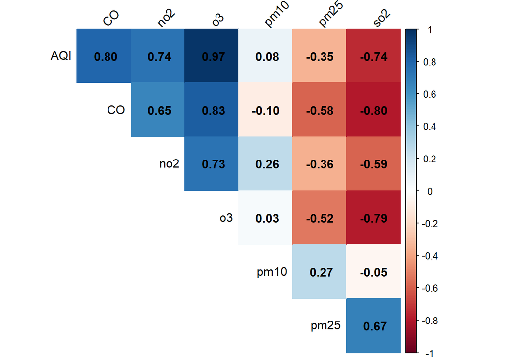

```r
corrplot(cor_matrix,
         method = "color",
         type = "upper",
         addCoef.col = "black",
         tl.col = "black",
         tl.srt = 45,
         diag = FALSE)
```

```r
variabel_terkuat <- names(which.max(abs(korelasi)))
cat("Variabel yang paling berpengaruh pada AQI adalah:", variabel_terkuat, "\n")
```

```
## Variabel yang paling berpengaruh pada AQI adalah: o3
```

```r
model_aqi <- lm(as.formula(paste("AQI ~", variabel_terkuat)), data=data_aqi)
summary(model_aqi)
```

```
##
## Call:
## lm(formula = as.formula(paste("AQI ~", variabel_terkuat)), data = data_aqi)
##
## Residuals:
##     Min      1Q  Median      3Q     Max
## -0.5039 -0.4436 -0.1381  0.1810  4.3810
##
## Coefficients:
##             Estimate Std. Error t value Pr(>|t|)
## (Intercept)  0.02128    0.73771   0.029    0.977
## o3           0.46241    0.01296  35.685   <2e-16 ***
## ---
## Signif. codes:  0 '***' 0.001 '**' 0.01 '*' 0.05 '.' 0.1 ' ' 1
##
## Residual standard error: 0.7022 on 70 degrees of freedom
## Multiple R-squared:  0.9479, Adjusted R-squared:  0.9472
## F-statistic:  1273 on 1 and 70 DF,  p-value: < 2.2e-16
```

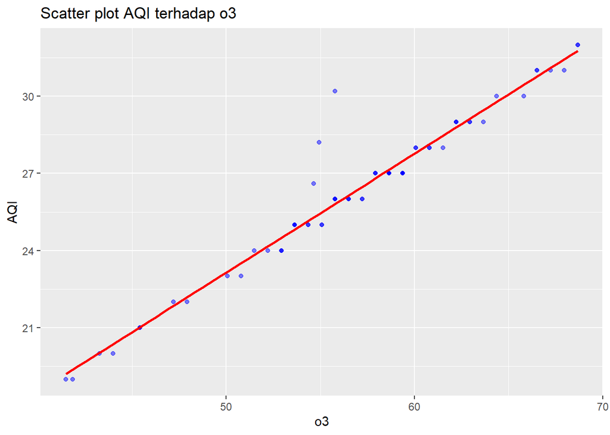

```r
library(ggplot2)
ggplot(data_aqi, aes_string(x=variabel_terkuat, y="AQI")) +
  geom_point(alpha=0.5, color="blue") +
  geom_smooth(method="lm", se=FALSE, color="red") +
  labs(title=paste("Scatter plot AQI terhadap", variabel_terkuat))
```

Saya memilih variabel ozon (O₃) karena memiliki korelasi tertinggi dengan AQI, yaitu 0,97, menunjukkan hubungan linier yang sangat kuat dan positif. Model regresi linear menunjukkan R² = 0,9479, artinya hampir 95% variasi AQI dapat dijelaskan oleh perubahan variabel O₃. Dari scatter plot, titik-titik data mengikuti pola naik yang sangat linear dan hampir semua berada dekat garis regresi, memperkuat bahwa ozon adalah variabel dominan yang mempengaruhi kualitas udara. Setelah membuat model regresi antara ozon (O₃) dan AQI, perlu mengecek apakah modelnya sudah ‘sehat’. Hal ini meliputi uji autokorelasi residual, normalitas residual, dan homoskedastisitas.

# Time Series Plot dan Uji Asumsi Klasik

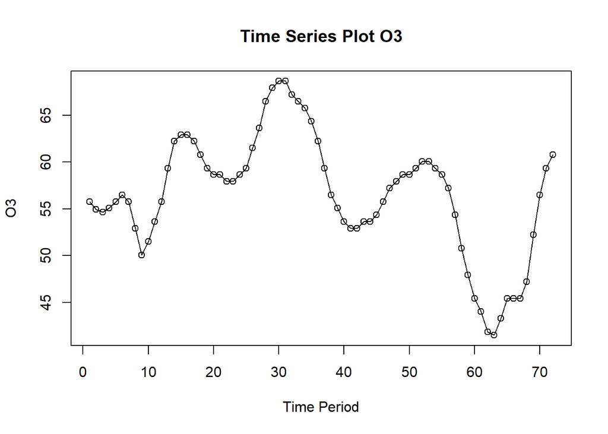

```r
ts.plot(data_aqi$o3, xlab="Time Period", ylab="O3",
        main = "Time Series Plot O3")
points(data_aqi$o3)
```

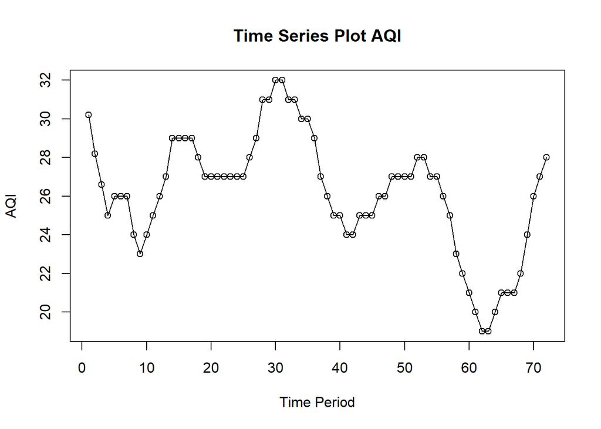

```r
ts.plot(data_aqi$AQI, xlab="Time Period", ylab="AQI",
        main = "Time Series Plot AQI")
points(data_aqi$AQI)
```

```r
# Autokorelasi residual
dwtest(model_aqi)
```

```
##
##  Durbin-Watson test
##
## data:  model_aqi
## DW = 0.54636, p-value = 3.207e-14
## alternative hypothesis: true autocorrelation is greater than 0
```

Karena p-value = 3.207e-14 < 0,05, kita menolak H0. Ini menunjukkan bahwa residual model regresi memiliki autokorelasi positif yang signifikan.

```r
# Normalitas residual
shapiro.test(residuals(model_aqi))
```

```
##
##  Shapiro-Wilk normality test
##
## data:  residuals(model_aqi)
## W = 0.51931, p-value = 5.517e-14
```

Karena p-value = 5.517e-14 < 0,05, H0 ditolak, yang berarti residual model tidak terdistribusi normal.”

```r
# Homoskedastisitas
bptest(model_aqi)
```

```
##
##  studentized Breusch-Pagan test
##
## data:  model_aqi
## BP = 0.039736, df = 1, p-value = 0.842
```

Karena p-value = 0,842 > 0,05, H0 diterima, yang menunjukkan bahwa residual memiliki ragam yang homogen.”

# Pembagian Data

```r
train <- data_aqi[1:58, ]
test  <- data_aqi[59:72, ]

# Membuat objek time series
train.ts <- ts(train)
test.ts  <- ts(test)
data.ts  <- ts(data_aqi)
```

# Model Koyck

```r
model.koyck <- koyckDlm(x = train$o3, y = train$AQI)
summary(model.koyck)
```

```
##
## Call:
## "Y ~ (Intercept) + Y.1 + X.t"
##
## Residuals:
##       Min        1Q    Median        3Q       Max
## -1.112282 -0.366467 -0.002877  0.258311  1.106529
##
## Coefficients:
##             Estimate Std. Error t value Pr(>|t|)
## (Intercept)  0.26260    0.93950   0.280    0.781
## Y.1          0.42943    0.08641   4.969 7.14e-06 ***
## X.t          0.25823    0.04259   6.064 1.35e-07 ***
## ---
## Signif. codes:  0 '***' 0.001 '**' 0.01 '*' 0.05 '.' 0.1 ' ' 1
##
## Residual standard error: 0.5239 on 54 degrees of freedom
## Multiple R-Squared: 0.9449,  Adjusted R-squared: 0.9429
## Wald test: 417.1 on 2 and 54 DF,  p-value: < 2.2e-16
##
## Diagnostic tests:
## NULL
##
##                             alpha      beta       phi
## Geometric coefficients:  0.460243 0.2582336 0.4294305
```

```r
AIC(model.koyck)
```

```
## [1] 92.98106
```

```r
BIC(model.koyck)
```

```
## [1] 101.1533
```

Model Koyck menghasilkan persamaan:
$$\hat{Y_t}=0.26260+0.25823X_t+0.42943Y_{t-1}$$

Koefisien O₃ saat ini ($X_t$ = 0,2582) signifikan, menandakan konsentrasi ozon berpengaruh langsung terhadap AQI. Koefisien lag AQI sebelumnya ($Y_{t-1}$ = 0,4294) juga signifikan, menunjukkan sekitar 43% efek periode sebelumnya terbawa ke periode saat ini.

### Peramalan dan Akurasi

Berikut adalah hasil peramalan y untuk 14 periode kedepan menggunakan model koyck.

```r
fore.koyck <- forecast(model.koyck, x=test$o3, h=14)
mape.koyck <- MAPE(fore.koyck$forecasts, test$AQI)
mape.koyck
```

```
## [1] 0.02909543
```

```r
GoF(model.koyck)
```

```
##              n     MAE           MPE       MAPE      sMAPE      MASE      MSE
## model.koyck 57 0.39765 -0.0005611615 0.01494044 0.01491151 0.5986129 0.260024
##                  MRAE    GMRAE
## model.koyck 545222624 5097.033
```

MAPE pada data training 1,49% dan pada data testing 2,91%, menunjukkan kesalahan prediksi sangat rendah (<10%). Nilai MAPE yang berada di bawah 10% mengindikasikan bahwa kesalahan peramalan model relatif sangat kecil.

# Regression with Distributed Lag

### Pemodelan (Misal Lag=3)

```r
model.dlm <- dlm(x = train$o3, y = train$AQI, q = 3)
summary(model.dlm)
```

```
##
## Call:
## lm(formula = model.formula, data = design)
##
## Residuals:
##      Min       1Q   Median       3Q      Max
## -0.46771 -0.30217  0.00862  0.28459  0.37206
##
## Coefficients:
##             Estimate Std. Error t value Pr(>|t|)
## (Intercept) -0.55029    0.59970  -0.918    0.363
## x.t          0.47549    0.04500  10.568 2.43e-14 ***
## x.1          0.03845    0.09981   0.385    0.702
## x.2         -0.07281    0.10132  -0.719    0.476
## x.3          0.02903    0.04755   0.611    0.544
## ---
## Signif. codes:  0 '***' 0.001 '**' 0.01 '*' 0.05 '.' 0.1 ' ' 1
##
## Residual standard error: 0.2911 on 50 degrees of freedom
## Multiple R-squared:  0.9842, Adjusted R-squared:  0.9829
## F-statistic: 777.2 on 4 and 50 DF,  p-value: < 2.2e-16
##
## AIC and BIC values for the model:
##        AIC      BIC
## 1 27.10177 39.14577
```

```r
AIC(model.dlm)
```

```
## [1] 27.10177
```

```r
BIC(model.dlm)
```

```
## [1] 39.14577
```

$$\hat{Y_t}=-0.55029+0.47549X_t+0.03845X_1-0.07281X_2+0.02903X_{t-3}$$

### Peramalan dan Akurasi

Berikut merupakan hasil peramalan $y$ untuk 14 periode kedepan

```r
fore.dlm <- forecast(model = model.dlm, x=test$o3, h=14)
fore.dlm
```

```
## $forecasts
##  [1] 21.89234 20.76931 20.09733 19.12124 18.90016 19.85135 20.90414 20.84607
##  [9] 20.74175 21.65430 24.10373 26.20664 27.41942 28.04253
##
## $call
## forecast.dlm(model = model.dlm, x = test$o3, h = 14)
##
## attr(,"class")
## [1] "forecast.dlm" "dLagM"
```

```r
mape.dlm <- MAPE(fore.dlm$forecasts, test$AQI)
mape.dlm
```

```
## [1] 0.00778879
```

```r
#akurasi data training
GoF(model.dlm)
```

```
##            n       MAE           MPE        MAPE       sMAPE      MASE
## model.dlm 55 0.2412266 -9.770146e-05 0.008946519 0.008940958 0.3831246
##                 MSE      MRAE   GMRAE
## model.dlm 0.0770501 986225471 5879.35
```

### *Lag* Optimum

```r
#penentuan lag optimum
finiteDLMauto(formula = AQI ~ o3,
              data = data.frame(train), q.min = 1, q.max = 10,
              model.type = "dlm", error.type = "AIC", trace = TRUE)
```

```
##    q - k    MASE      AIC      BIC     GMRAE   MBRAE R.Adj.Sq  Ljung-Box
## 10    10 0.33647 24.10757 48.43318 10779.390 0.48008  0.98393 0.41122212
## 5      5 0.36542 27.02479 42.78712  6410.480 0.48192  0.98352 0.18919655
## 3      3 0.38312 27.10177 39.14577  5879.350 0.48128  0.98290 0.11147130
## 4      4 0.38276 27.96420 41.88709  7635.896 0.48443  0.98283 0.17399541
## 6      6 0.36302 29.64290 47.20409  4742.320 0.47166  0.98307 0.19759073
## 9      9 0.36482 30.09649 52.79833  8867.244 0.48588  0.98222 0.76300049
## 7      7 0.37392 30.57737 49.89563  5848.238 0.47755  0.98314 0.27764544
## 8      8 0.38196 31.33341 52.36567  8039.153 0.49778  0.98265 0.41731544
## 2      2 0.41082 47.04815 57.17490  5489.740 0.47425  0.97492 0.08786534
## 1      1 0.48746 91.76306 99.93527  5751.269 0.38586  0.94411 0.16242279
```

Berdasarkan AIC terkecil yaitu 24.10757, lag optimum ditentukan pada q = 10, artinya pengaruh konsentrasi O₃ diperhitungkan hingga 10 periode sebelumnya. Selanjutnya dilakukan pemodelan untuk lag=10

```r
#model dlm dengan lag optimum
model.dlm2 <- dlm(x = train$o3, y = train$AQI, q = 10)

summary(model.dlm2)
```

```
##
## Call:
## lm(formula = model.formula, data = design)
##
## Residuals:
##      Min       1Q   Median       3Q      Max
## -0.48304 -0.17355  0.04636  0.17934  0.52554
##
## Coefficients:
##             Estimate Std. Error t value Pr(>|t|)
## (Intercept) -0.64267    0.89957  -0.714  0.47958
## x.t          0.42814    0.06180   6.928 4.08e-08 ***
## x.1          0.13889    0.13339   1.041  0.30473
## x.2         -0.05734    0.12788  -0.448  0.65654
## x.3         -0.14994    0.12237  -1.225  0.22840
## x.4          0.15911    0.12493   1.274  0.21095
## x.5         -0.01335    0.12436  -0.107  0.91510
## x.6         -0.12709    0.12430  -1.022  0.31338
## x.7          0.27371    0.12253   2.234  0.03180 *
## x.8         -0.37459    0.12097  -3.097  0.00378 **
## x.9          0.28924    0.10409   2.779  0.00862 **
## x.10        -0.09537    0.04837  -1.971  0.05640 .
## ---
## Signif. codes:  0 '***' 0.001 '**' 0.01 '*' 0.05 '.' 0.1 ' ' 1
##
## Residual standard error: 0.2739 on 36 degrees of freedom
## Multiple R-squared:  0.9877, Adjusted R-squared:  0.9839
## F-statistic: 262.6 on 11 and 36 DF,  p-value: < 2.2e-16
##
## AIC and BIC values for the model:
##        AIC      BIC
## 1 24.10757 48.43318
```

```r
AIC(model.dlm2)
```

```
## [1] 24.10757
```

```r
BIC(model.dlm2)
```

```
## [1] 48.43318
```

Dari hasil tersebut terdapat 4 peubah yang berpengaruh signifikan yaitu $x_t$ , $x_{t-7}$ , $x_{t-8}$ , $x_{t-9}$. Model yang terbentuk adalah:

$$\hat{Y_t}=-0.6427+0.4281X_t+0.13889X_1+...-0.09537X_{t-10}$$

Adapun hasil peramalan 14 periode kedepan menggunakan model tersebut adalah sebagai berikut:

```r
fore.dlm2 <- forecast(model = model.dlm2, x=test$o3, h=14)
fore.dlm2
```

```
## $forecasts
##  [1] 21.71254 20.68921 20.02702 19.13710 18.76899 19.53092 20.95694 21.06735
##  [9] 20.45470 21.52028 23.77255 26.47778 27.61003 27.92625
##
## $call
## forecast.dlm(model = model.dlm2, x = test$o3, h = 14)
##
## attr(,"class")
## [1] "forecast.dlm" "dLagM"
```

```r
mape.dlm2 <- MAPE(fore.dlm2$forecasts, test$AQI)
mape.dlm2
```

```
## [1] 0.0127254
```

```r
# Akurasi data training
GoF(model.dlm2)
```

```
##             n       MAE           MPE        MAPE       sMAPE     MASE
## model.dlm2 48 0.2004478 -7.414126e-05 0.007373085 0.007368538 0.336466
##                   MSE      MRAE    GMRAE
## model.dlm2 0.05628638 896417348 10779.39
```

MAPE pada data testing sebesar <10%, menunjukkan model DLM mampu memprediksi AQI dengan sangat baik.

# Model Autoregressive

```r
model.ardl1 <- ardlDlm(x = train$o3, y = train$AQI, p = 1, q = 1)
summary(model.ardl1)
```

```
##
## Time series regression with "ts" data:
## Start = 2, End = 58
##
## Call:
## dynlm(formula = as.formula(model.text), data = data, start = 1)
##
## Residuals:
##     Min      1Q  Median      3Q     Max
## -1.0233 -0.2713  0.1217  0.2984  0.8689
##
## Coefficients:
##             Estimate Std. Error t value Pr(>|t|)
## (Intercept) -0.24530    0.66489  -0.369    0.714
## X.t          0.48660    0.03236  15.036  < 2e-16 ***
## X.1         -0.23184    0.04540  -5.106 4.56e-06 ***
## Y.1          0.45632    0.06613   6.901 6.51e-09 ***
## ---
## Signif. codes:  0 '***' 0.001 '**' 0.01 '*' 0.05 '.' 0.1 ' ' 1
##
## Residual standard error: 0.3797 on 53 degrees of freedom
## Multiple R-squared:  0.9716, Adjusted R-squared:   0.97
## F-statistic: 604.7 on 3 and 53 DF,  p-value: < 2.2e-16
```

```r
AIC(model.ardl1)
```

```
## [1] 57.2222
```

```r
BIC(model.ardl1)
```

```
## [1] 67.43746
```

```r
model.ardl1 <- ardlDlm(AQI ~ o3, data = data_aqi, p = 1, q = 1)

X <- test$o3[1:14]

fore.ardl1 <- fore_ardl <- dLagM::forecast(model.ardl1, x = X, h = 14)
fore.ardl1
```

```
## $forecasts
##  [1] 21.92106 20.80730 20.17475 19.18631 19.04002 19.89849 20.91061 20.89829
##  [9] 20.89274 21.73661 24.09632 26.09796 27.41731 28.06441
##
## $call
## forecast.ardlDlm(model = model.ardl1, x = X, h = 14)
##
## attr(,"class")
## [1] "forecast.ardlDlm" "dLagM"
```

```r
# Akurasi data test
mape.ardl1 <- MAPE(fore.ardl1$forecasts, test$AQI)
mape.ardl1
```

```
## [1] 0.00644334
```

```r
# Akurasi data training
GoF(model.ardl1)
```

```
##              n       MAE           MPE       MAPE      sMAPE      MASE
## model.ardl1 71 0.2793787 -0.0001451439 0.01057895 0.01056969 0.3895718
##                   MSE      MRAE    GMRAE
## model.ardl1 0.1136912 888010397 1904.261
```

```r
model.ardl.opt <- ardlBoundOrders(data = data.frame(data_aqi), ic = "AIC", formula = AQI ~ o3)
```

### *Lag* Optimum

```r
# Tentukan lag optimum
min_p <- sapply(1:length(model.ardl.opt$Stat.table), function(i) min(model.ardl.opt$Stat.table[[i]], na.rm=TRUE))
q_opt <- which(min_p == min(min_p, na.rm=TRUE))
p_opt <- which(model.ardl.opt$Stat.table[[q_opt]] == min(model.ardl.opt$Stat.table[[q_opt]], na.rm=TRUE))
data.frame("q_optimum"=q_opt, "p_optimum"=p_opt, "AIC"=model.ardl.opt$min.Stat)
```

```
##   q_optimum p_optimum      AIC
## 1         2        13 16.55044
```

Dari tabel di atas, dapat terlihat bahwa nilai AIC terendah didapat ketika $p=13$ dan $q=2$. Artinya, model autoregressive optimum didapat ketika $p=13$ dan $q=2$.

Selanjutnya dapat dilakukan pemodelan dengan nilai $p$ dan $q$ optimum.

### Pemodelan (p=13, q=2)

```r
library(dLagM)
model.ardl2 <- ardlDlm(formula = AQI ~ o3, data = train, p = 13, q = 2)
summary(model.ardl2)
```

```
##
## Time series regression with "ts" data:
## Start = 14, End = 58
##
## Call:
## dynlm(formula = as.formula(model.text), data = data)
##
## Residuals:
##      Min       1Q   Median       3Q      Max
## -0.41430 -0.19394  0.02836  0.16087  0.47584
##
## Coefficients:
##             Estimate Std. Error t value Pr(>|t|)
## (Intercept) -1.04456    1.06711  -0.979   0.3360
## o3.t         0.40658    0.06938   5.860 2.67e-06 ***
## o3.1         0.20835    0.18174   1.146   0.2613
## o3.2        -0.09590    0.20134  -0.476   0.6376
## o3.3        -0.13900    0.15910  -0.874   0.3897
## o3.4         0.07385    0.15906   0.464   0.6460
## o3.5         0.05911    0.14382   0.411   0.6842
## o3.6        -0.15248    0.13442  -1.134   0.2663
## o3.7         0.25536    0.13453   1.898   0.0680 .
## o3.8        -0.28691    0.14185  -2.023   0.0528 .
## o3.9         0.12287    0.15600   0.788   0.4375
## o3.10        0.13887    0.15975   0.869   0.3921
## o3.11       -0.20179    0.14670  -1.376   0.1799
## o3.12        0.05814    0.12013   0.484   0.6322
## o3.13        0.01800    0.05426   0.332   0.7426
## AQI.1       -0.11385    0.19128  -0.595   0.5565
## AQI.2        0.14225    0.18763   0.758   0.4547
## ---
## Signif. codes:  0 '***' 0.001 '**' 0.01 '*' 0.05 '.' 0.1 ' ' 1
##
## Residual standard error: 0.2851 on 28 degrees of freedom
## Multiple R-squared:  0.9892, Adjusted R-squared:  0.9831
## F-statistic: 160.6 on 16 and 28 DF,  p-value: < 2.2e-16
```

```r
AIC(model.ardl2)
```

```
## [1] 29.42385
```

```r
BIC(model.ardl2)
```

```
## [1] 61.94377
```

Model keseluruhannya adalah sebagai berikut:

$$\hat{Y_t}=-1.04456+0.407X_t+0.208X_{t-1}+...+0.14225Y_{t-2}$$

```r
fore.ardl2 <- forecast(model = model.ardl2, x=test$o3, h=14)
fore.ardl2
```

```
## $forecasts
##  [1] 21.77229 20.52108 20.02939 19.14999 18.73570 19.45331 20.86257 21.11623
##  [9] 20.47743 21.43916 23.65285 26.32716 27.71046 27.92030
##
## $call
## forecast.ardlDlm(model = model.ardl2, x = test$o3, h = 14)
##
## attr(,"class")
## [1] "forecast.ardlDlm" "dLagM"
```

```r
# MAPE data uji
mape.ardl2 <- MAPE(fore.ardl2$forecasts, test$AQI)
mape.ardl2
```

```
## [1] 0.01445912
```

```r
# Akurasi data latih
GoF(model.ardl2)
```

```
##              n       MAE           MPE       MAPE       sMAPE      MASE
## model.ardl2 45 0.1934879 -6.779947e-05 0.00711318 0.007110808 0.3547279
##                    MSE      MRAE    GMRAE
## model.ardl2 0.05058937 932166881 19290.28
```

Terlihat nilai MAPE yang berada di bawah 10% mengindikasikan bahwa kesalahan peramalan model relatif sangat kecil. Nilai MAPE keduanya tidak jauh berbeda. Artinya, model regresi dengan distribusi lag ini tidak overfitted atau underfitted.

# Pemodelan DLM & ARDL dengan Library `dynlm`

```r
# Model DLM sama seperti q=10 (lag O3 1 sampai 10)
cons_lm1 <- dynlm(AQI ~ o3 + L(o3, 1:10), data = train.ts)

# Model ARDL sama seperti p=13, q=2 (lag AQI 1 sampai 13, lag O3 0 sampai 2)
cons_lm2 <- dynlm(AQI ~ L(AQI, 1:13) + L(o3, 0:2), data = train.ts)
```

### Ringkasan Model

```r
summary(cons_lm1)
```

```
##
## Time series regression with "ts" data:
## Start = 11, End = 58
##
## Call:
## dynlm(formula = AQI ~ o3 + L(o3, 1:10), data = train.ts)
##
## Residuals:
##      Min       1Q   Median       3Q      Max
## -0.48304 -0.17355  0.04636  0.17934  0.52554
##
## Coefficients:
##               Estimate Std. Error t value Pr(>|t|)
## (Intercept)   -0.64267    0.89957  -0.714  0.47958
## o3             0.42814    0.06180   6.928 4.08e-08 ***
## L(o3, 1:10)1   0.13889    0.13339   1.041  0.30473
## L(o3, 1:10)2  -0.05734    0.12788  -0.448  0.65654
## L(o3, 1:10)3  -0.14994    0.12237  -1.225  0.22840
## L(o3, 1:10)4   0.15911    0.12493   1.274  0.21095
## L(o3, 1:10)5  -0.01335    0.12436  -0.107  0.91510
## L(o3, 1:10)6  -0.12709    0.12430  -1.022  0.31338
## L(o3, 1:10)7   0.27371    0.12253   2.234  0.03180 *
## L(o3, 1:10)8  -0.37459    0.12097  -3.097  0.00378 **
## L(o3, 1:10)9   0.28924    0.10409   2.779  0.00862 **
## L(o3, 1:10)10 -0.09537    0.04837  -1.971  0.05640 .
## ---
## Signif. codes:  0 '***' 0.001 '**' 0.01 '*' 0.05 '.' 0.1 ' ' 1
##
## Residual standard error: 0.2739 on 36 degrees of freedom
## Multiple R-squared:  0.9877, Adjusted R-squared:  0.9839
## F-statistic: 262.6 on 11 and 36 DF,  p-value: < 2.2e-16
```

```r
summary(cons_lm2)
```

```
##
## Time series regression with "ts" data:
## Start = 14, End = 58
##
## Call:
## dynlm(formula = AQI ~ L(AQI, 1:13) + L(o3, 0:2), data = train.ts)
##
## Residuals:
##      Min       1Q   Median       3Q      Max
## -0.48900 -0.22295 -0.01183  0.19326  0.47401
##
## Coefficients:
##                 Estimate Std. Error t value Pr(>|t|)
## (Intercept)    -1.237853   1.191574  -1.039    0.308
## L(AQI, 1:13)1  -0.205269   0.191777  -1.070    0.294
## L(AQI, 1:13)2  -0.009811   0.194528  -0.050    0.960
## L(AQI, 1:13)3  -0.014613   0.158955  -0.092    0.927
## L(AQI, 1:13)4  -0.064092   0.121946  -0.526    0.603
## L(AQI, 1:13)5   0.070824   0.123267   0.575    0.570
## L(AQI, 1:13)6  -0.083122   0.117381  -0.708    0.485
## L(AQI, 1:13)7   0.086451   0.113824   0.760    0.454
## L(AQI, 1:13)8  -0.027234   0.111727  -0.244    0.809
## L(AQI, 1:13)9  -0.018867   0.110882  -0.170    0.866
## L(AQI, 1:13)10  0.082003   0.101493   0.808    0.426
## L(AQI, 1:13)11 -0.084207   0.104545  -0.805    0.427
## L(AQI, 1:13)12 -0.037109   0.104337  -0.356    0.725
## L(AQI, 1:13)13  0.064659   0.063802   1.013    0.320
## L(o3, 0:2)0     0.455077   0.086392   5.268 1.33e-05 ***
## L(o3, 0:2)1     0.134293   0.228457   0.588    0.561
## L(o3, 0:2)2     0.002710   0.224250   0.012    0.990
## ---
## Signif. codes:  0 '***' 0.001 '**' 0.01 '*' 0.05 '.' 0.1 ' ' 1
##
## Residual standard error: 0.317 on 28 degrees of freedom
## Multiple R-squared:  0.9867, Adjusted R-squared:  0.9791
## F-statistic: 129.6 on 16 and 28 DF,  p-value: < 2.2e-16
```

### SSE

```r
deviance(cons_lm1)
```

```
## [1] 2.701746
```

```r
deviance(cons_lm2)
```

```
## [1] 2.813403
```

#### Autokorelasi

```r
#durbin watson
dwtest(cons_lm1)
```

```
##
##  Durbin-Watson test
##
## data:  cons_lm1
## DW = 2.1908, p-value = 0.5901
## alternative hypothesis: true autocorrelation is greater than 0
```

```r
dwtest(cons_lm2)
```

```
##
##  Durbin-Watson test
##
## data:  cons_lm2
## DW = 1.9978, p-value = 0.3242
## alternative hypothesis: true autocorrelation is greater than 0
```

#### Heterogenitas

```r
bptest(cons_lm1)
```

```
##
##  studentized Breusch-Pagan test
##
## data:  cons_lm1
## BP = 9.774, df = 11, p-value = 0.5508
```

```r
bptest(cons_lm2)
```

```
##
##  studentized Breusch-Pagan test
##
## data:  cons_lm2
## BP = 15.088, df = 16, p-value = 0.5182
```

#### Kenormalan

```r
shapiro.test(residuals(cons_lm1))
```

```
##
##  Shapiro-Wilk normality test
##
## data:  residuals(cons_lm1)
## W = 0.96818, p-value = 0.2149
```

```r
shapiro.test(residuals(cons_lm2))
```

```
##
##  Shapiro-Wilk normality test
##
## data:  residuals(cons_lm2)
## W = 0.96659, p-value = 0.2168
```

## Perbandingan Model

```r
# Buat matriks akurasi
akurasi <- matrix(
  c(mape.koyck, mape.dlm, mape.dlm2, mape.ardl1, mape.ardl2),
  nrow = 5,
  byrow = TRUE
)

row.names(akurasi) <- c("Koyck", "DLM 1", "DLM 2", "Autoregressive 1", "Autoregressive 2")
colnames(akurasi) <- c("MAPE")

akurasi
```

```
##                        MAPE
## Koyck            0.02909543
## DLM 1            0.00778879
## DLM 2            0.01272540
## Autoregressive 1 0.00644334
## Autoregressive 2 0.01445912
```

Nilai MAPE terkecil diperoleh pada Autoregressive, sehingga model ini menjadi pilihan terbaik. Ini menunjukkan bahwa model ini paling efektif dalam menangkap hubungan dinamis antara variabel O₃ dan AQI. Dengan kesalahan prediksi terendah, model ini memberikan estimasi AQI yang paling akurat dibandingkan model lain.

### Plot

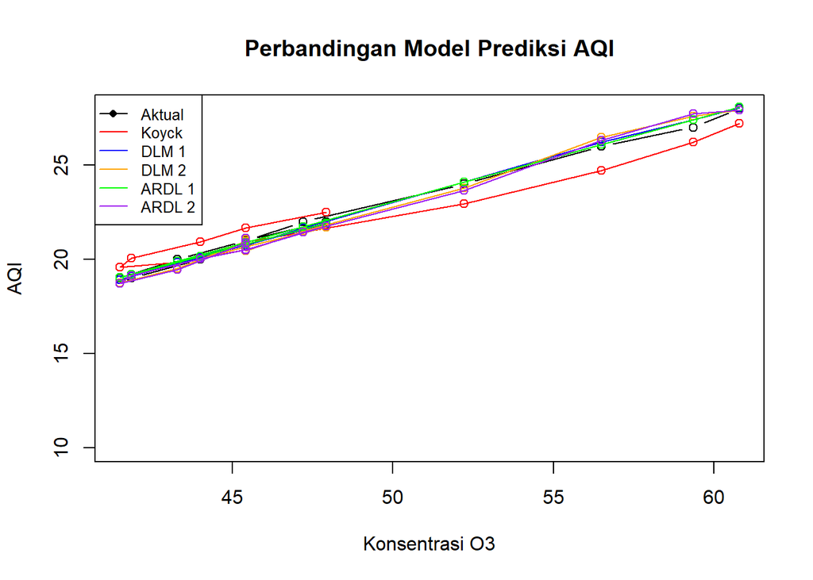

```r
par(mfrow=c(1,1))
plot(test$o3, test$AQI, type="b", col="black", ylim=c(10,28),
     xlab="Konsentrasi O3", ylab="AQI", main="Perbandingan Model Prediksi AQI")

# Tambahkan model
points(test$o3, fore.koyck$forecasts, col="red")
lines(test$o3, fore.koyck$forecasts, col="red")

points(test$o3, fore.dlm$forecasts, col="blue")
lines(test$o3, fore.dlm$forecasts, col="blue")

points(test$o3, fore.dlm2$forecasts, col="orange")
lines(test$o3, fore.dlm2$forecasts, col="orange")

points(test$o3, fore.ardl1$forecasts, col="green")
lines(test$o3, fore.ardl1$forecasts, col="green")

points(test$o3, fore.ardl2$forecasts, col="purple")
lines(test$o3, fore.ardl2$forecasts, col="purple")

# Legend
legend("topleft",
       legend=c("Aktual", "Koyck", "DLM 1", "DLM 2", "ARDL 1", "ARDL 2"),
       col=c("black","red","blue","orange","green","purple"),
       lty=1, pch=c(16, NA, NA, NA, NA, NA),
       cex=0.8)
```